# R Notebook

# Load libraries

```r
#install.packages(c("readxl","ggplot2","tidyverse","purrr","knitr","magrittr",
#"openxlsx","labelled","dplyr","here", "metafor"))
library(readxl)
library(tidyverse)
library(openxlsx)
library(dplyr)
library(here)
library(metafor)
```

# Load clean datafile

This file assumes that `0_data-cleaning.Rmd` has been previouly run to update rds file in data folder.

```r
effects_evaluations <- readRDS(here("data","cleanDatafile.rds"))
  #filter(jovenes!="menor a 25")
effects_evaluations %>%
  filter(outcome_type == 1) %>%
  distinct(evaluation_id)
```

| evaluation_id |
| --- |
| Acero 2009 |
| Acevedo 2017 i |
| Acevedo 2017 ii |
| Adoho 2014 i |
| Alcid 2014 |
| Alvares de Azevedo 2013 i |
| Alvares de Azevedo 2013 ii |
| Attanasio 2011 |
| Schochet 2008 |
| Bausch 2016 |

[output cut: 62 more lines]

# Constructions of dataset with evaluations, effects and SE

## Are there estimates with gender == “pooled” but age_group != NA?

First, let’s find out if there are estimates that are provided for `gender == "pooled"` but `age_group` is `NA`, that means that is for the whole sample.

```r
df1 <- effects_evaluations %>%
  filter(outcome_type == 1,
         is.na(age_group),
         gender == "pooled") %>%
  select(1,2) %>%
  distinct()
df2 <- effects_evaluations %>%
  filter(outcome_type == 1,
         gender == "pooled") %>%
  select(1,2) %>%
  distinct()
anti_join(df2, df1, by = c("paper_id", "evaluation_id"))
```

| paper_id | evaluation_id |
| --- | --- |

```r
anti_join(df1, df2, by = c("paper_id", "evaluation_id"))
```

| paper_id | evaluation_id |
| --- | --- |

```r
rm(df1, df2)
```

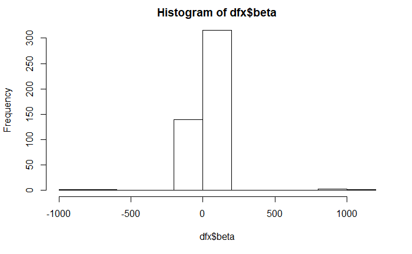

```r
dfx<- effects_evaluations %>%
  filter(outcome_type == 1)
hist(dfx$beta)
```

All papers that have gender == “pooled” also provide an estimate for the whole sample in age.

## Collapse evaluations with gender pooled and age pooled

Now, we add to a dataset the combined effect for evaluations that have one or more effects type 1. We only consider effects for `gender == "pooled"` and for the whole sample (`age_group == NA`)

To combine the effect accross different `months_of_delay`, we use the function `combineEffectsAcrossTime` with correlation equal to `0.5`.

```r
#ver como son los efectos a combinar en orden de tiempo
 employment_ver <- effects_evaluations %>%
  filter(outcome_type == 1,
         gender == "pooled",
         is.na(age_group)) %>%
  arrange(evaluation_id,paper_id, months_of_delay)
```

```r
employment_meta <- effects_evaluations %>%
  filter(outcome_type == 1,
         gender == "pooled",
         is.na(age_group)) %>%
  group_by(evaluation_id) %>%
  summarise(y = combineEffectsAcrossTime(y = beta, se = se_calculated)[1],
            se = combineEffectsAcrossTime(y = beta, se = se_calculated)[2],
            number_effects = n())
employment_meta <- employment_meta %>%
  mutate(gender = "pooled") %>%
  select(evaluation_id, gender, y:number_effects)
employment_meta
```

| evaluation_id | gender | y | se | number_effects |
| --- | --- | --- | --- | --- |
| Acero 2009 | pooled | 0.014250000 | 1.623401e-02 | 4 |
| Alcid 2014 | pooled | 0.119000000 | 2.400000e-02 | 1 |
| Alvares de Azevedo 2013 i | pooled | 0.140000000 | 5.000000e-02 | 1 |
| Alvares de Azevedo 2013 ii | pooled | 0.090000000 | 5.000000e-02 | 1 |
| Andrén 2006 | pooled | 0.008850000 | 3.030937e-02 | 2 |
| Attanasio 2011 | pooled | 0.048000000 | 2.300000e-02 | 1 |
| Bausch 2016 | pooled | -0.063000000 | 3.400000e-02 | 1 |
| Butler 2012 i | pooled | 0.031000000 | 2.210225e-02 | 1 |
| Butler 2012 ii | pooled | 0.015000000 | 2.218056e-02 | 1 |
| Calero 2016 | pooled | 0.110000000 | 5.634714e-02 | 2 |

[output cut: 44 more lines]

## Are there effects not reported for gender == “pooled” and is.na(age_group)

We want to find the effects that are reported separated for women and men, and not aggregated. Also, we want these effects to be for the whole sample in regard to age (that is `age_group == NA`)

First, we find the effects without pool estimate

```r
df1 <- effects_evaluations %>%
  filter(outcome_type == 1, gender == "pooled") %>%
  select(evaluation_id) %>%
  distinct()
df2 <- effects_evaluations %>%
  filter(outcome_type == 1, gender %in% c("male","female")) %>%
  select(evaluation_id) %>%
  distinct()
evaluation_female_or_male <- anti_join(df2,df1, by ="evaluation_id")
evaluation_female_or_male
```

| evaluation_id |
| --- |
| Acevedo 2017 i |
| Acevedo 2017 ii |
| Adoho 2014 i |
| Biewen 2014 i |
| Biewen 2014 ii |
| Fitzenberger 2000 |
| GAO 1996 |
| Groh 2016 |
| Honorati 2015 |
| Maitra 2017 |

[output cut: 8 more lines]

From this group of evaluations, we want to make sure that there are effects for the whole sample in regard to age:

```r
effects_gender_all_ages <- effects_evaluations %>%
  filter(outcome_type == 1,
         evaluation_id %in% pull(evaluation_female_or_male),
         is.na(age_group)) %>%
  select(2) %>%
  distinct()
anti_join(evaluation_female_or_male, effects_gender_all_ages, by="evaluation_id")
```

| evaluation_id |
| --- |
| GAO 1996 |

From this, there is a problematic paper (GAO 1996), that provides independent estimates for males and females, and for different age ranges, not for the whole sample. We will deal with GAO separately.

## Collapsing by effects by gender and creating a pooled estimated

Now, we need to have only one estimate for each gender/paper_id/evaluation_id,

```r
effects_collapsed_by_gender <- effects_evaluations %>%
  filter(outcome_type == 1,
         evaluation_id %in% pull(evaluation_female_or_male),
         is.na(age_group)) %>%
  group_by(evaluation_id, gender) %>%
  summarise(beta = combineEffectsAcrossTime(y = beta, se = se_calculated)[1],
            se = combineEffectsAcrossTime(y = beta, se = se_calculated)[2],
            number_effects = n())
effects_collapsed_by_gender
```

| evaluation_id | gender | beta | se | number_effects |
| --- | --- | --- | --- | --- |
| Acevedo 2017 i | female | 0.04300000 | 0.02700000 | 2 |
| Acevedo 2017 i | male | -0.06000000 | 0.04000000 | 2 |
| Acevedo 2017 ii | female | 0.03250000 | 0.02500000 | 2 |
| Acevedo 2017 ii | male | -0.02000000 | 0.03800000 | 2 |
| Adoho 2014 i | female | 0.14500000 | 0.03900000 | 1 |
| Auspos 1988 | female | 0.04440000 | 0.04479553 | 5 |
| Biewen 2014 i | female | 0.06200000 | 0.01600000 | 6 |
| Biewen 2014 i | male | 0.02283333 | 0.13000000 | 6 |
| Biewen 2014 ii | female | -0.02666667 | 0.02200000 | 6 |
| Biewen 2014 ii | male | -0.05016667 | 0.18000000 | 6 |

[output cut: 16 more lines]

```r
effects_evaluation_with_gender <- effects_collapsed_by_gender %>%
  group_by(evaluation_id) %>%
  mutate(y_pooled = combineEffectsGender(y = beta, se = se)[1],
         se_pooled = combineEffectsGender(y = beta, se = se)[2],
         total_number_effects = sum(number_effects)) %>%
  ungroup() %>%
  mutate(gender_evaluation = ifelse(total_number_effects == number_effects, as.character(gender), "s.pooled"),
         gender_evaluation = parse_factor(gender_evaluation)) %>%
  select(-gender,-beta,-se) %>%
  distinct() %>%
  select(evaluation_id,
         gender = gender_evaluation,
         y = y_pooled,
         se = se_pooled,
         number_effects = total_number_effects )
effects_evaluation_with_gender
```

| evaluation_id | gender | y | se | number_effects |
| --- | --- | --- | --- | --- |
| Acevedo 2017 i | s.pooled | 1.075998e-02 | 0.02237891 | 4 |
| Acevedo 2017 ii | s.pooled | 1.664089e-02 | 0.02088543 | 4 |
| Adoho 2014 i | female | 1.450000e-01 | 0.03900000 | 1 |
| Auspos 1988 | female | 4.440000e-02 | 0.04479553 | 5 |
| Biewen 2014 i | s.pooled | 6.141556e-02 | 0.01588018 | 12 |
| Biewen 2014 ii | s.pooled | -2.701255e-02 | 0.02183750 | 12 |
| Bloom 1990 i | s.pooled | -8.609886e-03 | 0.01470159 | 2 |
| Bloom 1990 ii | s.pooled | -4.086259e-06 | 0.01046877 | 2 |
| Bloom 1990 iii | s.pooled | 2.629497e-02 | 0.03345066 | 2 |
| Burghardt 1992 ii | female | -4.000000e-03 | 0.03600000 | 1 |

[output cut: 7 more lines]

We combine with the previous table:

```r
employment_meta <- employment_meta %>%
  bind_rows(effects_evaluation_with_gender) %>%
  mutate(gender = parse_factor(gender))
```

```
binding character and factor vector, coercing into character vector
```

```r
employment_meta
```

| evaluation_id | gender | y | se | number_effects |
| --- | --- | --- | --- | --- |
| Acero 2009 | pooled | 1.425000e-02 | 1.623401e-02 | 4 |
| Alcid 2014 | pooled | 1.190000e-01 | 2.400000e-02 | 1 |
| Alvares de Azevedo 2013 i | pooled | 1.400000e-01 | 5.000000e-02 | 1 |
| Alvares de Azevedo 2013 ii | pooled | 9.000000e-02 | 5.000000e-02 | 1 |
| Andrén 2006 | pooled | 8.850000e-03 | 3.030937e-02 | 2 |
| Attanasio 2011 | pooled | 4.800000e-02 | 2.300000e-02 | 1 |
| Bausch 2016 | pooled | -6.300000e-02 | 3.400000e-02 | 1 |
| Butler 2012 i | pooled | 3.100000e-02 | 2.210225e-02 | 1 |
| Butler 2012 ii | pooled | 1.500000e-02 | 2.218056e-02 | 1 |
| Calero 2016 | pooled | 1.100000e-01 | 5.634714e-02 | 2 |

[output cut: 61 more lines]

## Dealing with GAO 1996

Now, we deal with GAO 1996. First, we collapse by age_group and gender:

```r
gao_summary <- effects_evaluations %>%
  filter(evaluation_id == "GAO 1996",
         outcome_type == 1) %>%
  group_by(evaluation_id, gender, age_group) %>%
  summarise(beta_combined_delay = combineEffectsAcrossTime(beta, se_calculated)[1],
            se_combined_delay = combineEffectsAcrossTime(beta, se_calculated)[2],
            number_effects = n()) %>%
  group_by(evaluation_id) %>%
  summarise(y = combineEffectsGender(beta_combined_delay, se_combined_delay)[1],
            se = combineEffectsGender(beta_combined_delay, se_combined_delay)[2],
            number_effects = sum(number_effects))  %>%
  mutate( gender = "s.pooled") %>%
  select(1, gender, 2:4)
gao_summary
```

| evaluation_id | gender | y | se | number_effects |
| --- | --- | --- | --- | --- |
| GAO 1996 | s.pooled | 0.01493553 | 0.007651975 | 20 |

```r
employment_meta <- employment_meta %>%
  bind_rows(gao_summary) %>%
  mutate(gender = parse_factor(gender))
```

```
binding factor and character vector, coercing into character vectorbinding character and factor vector, coercing into character vector
```

```r
employment_meta
```

| evaluation_id | gender | y | se | number_effects |
| --- | --- | --- | --- | --- |
| Acero 2009 | pooled | 1.425000e-02 | 1.623401e-02 | 4 |
| Alcid 2014 | pooled | 1.190000e-01 | 2.400000e-02 | 1 |
| Alvares de Azevedo 2013 i | pooled | 1.400000e-01 | 5.000000e-02 | 1 |
| Alvares de Azevedo 2013 ii | pooled | 9.000000e-02 | 5.000000e-02 | 1 |
| Andrén 2006 | pooled | 8.850000e-03 | 3.030937e-02 | 2 |
| Attanasio 2011 | pooled | 4.800000e-02 | 2.300000e-02 | 1 |
| Bausch 2016 | pooled | -6.300000e-02 | 3.400000e-02 | 1 |
| Butler 2012 i | pooled | 3.100000e-02 | 2.210225e-02 | 1 |
| Butler 2012 ii | pooled | 1.500000e-02 | 2.218056e-02 | 1 |
| Calero 2016 | pooled | 1.100000e-01 | 5.634714e-02 | 2 |

[output cut: 62 more lines]

# Create DTA file to continue analysis in Stata

```r
employment_meta_categories <- employment_meta %>%
  left_join(
    effects_evaluations %>%
      select(
      evaluation_id,
      skills:where_class,
      #length_intervention2,
      #length_intervention3,
      #length_intervention,
      skills_order,
      lac,

      ) %>%
      distinct(),
  by = "evaluation_id"
  )

  employment_meta_categories
```

| evaluation_id | gender | y | se | number_effects | skills | training | jovenes | implementer | where_internship | where_class | skills_order | lac |
| --- | --- | --- | --- | --- | --- | --- | --- | --- | --- | --- | --- | --- |
| Acero 2009 | pooled | 1.425000e-02 | 1.623401e-02 | 4 | Technical | Both | both | Government | Private-subsidized | Public | 2 | yes |
| Alcid 2014 | pooled | 1.190000e-01 | 2.400000e-02 | 1 | Technical | Both | both | Mulilateral_NGO | Private-subsidized | Private | 2 | no |
| Alvares de Azevedo 2013 i | pooled | 1.400000e-01 | 5.000000e-02 | 1 | Both | Both | both | Mulilateral_NGO | Private-subsidized | Private | 3 | no |
| Alvares de Azevedo 2013 ii | pooled | 9.000000e-02 | 5.000000e-02 | 1 | Technical | Both | both | Mulilateral_NGO | Private-subsidized | Private | 2 | no |
| Andrén 2006 | pooled | 8.850000e-03 | 3.030937e-02 | 2 | Technical | Classroom | both | Government | NA | Public | 2 | no |
| Attanasio 2011 | pooled | 4.800000e-02 | 2.300000e-02 | 1 | Both | Both | both | Government | Private-subsidized | Private | 3 | yes |
| Bausch 2016 | pooled | -6.300000e-02 | 3.400000e-02 | 1 | Both | Classroom | less than 25 | Government | NA | Private | 3 | no |
| Butler 2012 i | pooled | 3.100000e-02 | 2.210225e-02 | 1 | Technical | Both | menor a 25 | Private | private subsidized | Private | 2 | no |
| Butler 2012 ii | pooled | 1.500000e-02 | 2.218056e-02 | 1 | Soft | Classroom | menor a 25 | Mulilateral_NGO | NA | Private | 1 | no |
| Calero 2016 | pooled | 1.100000e-01 | 5.634714e-02 | 2 | Both | Classroom | both | Mulilateral_NGO | NA | Private | 3 | yes |

[output cut: 62 more lines]

```r
  write.dta(
    employment_meta_categories,
    file = here("data", "employment_meta_categories_v2.dta"),
    convert.factors = "string"
    )
```

# Meta-analysis